# Assignment 6 Key

Data Science for Biomedical Informatics (BMIN503/EPID600)

#### Gene Expression

2. Analyse GEO dataset GSE27973 to identify genes that are differentially expressed in airway epithelial cells in response to cigarette smoke extract (CSE) exposure. The procedure you need to follow is similar to that followed in Practicum 17. Specifically,
- Download the raw CEL files from GEO, create an expression set, and include a phenotype variable corresponding to `treatment` with four levels as can be inferred from the GEO submission.

```r
library(GEOquery)
getGEOSuppFiles("GSE27973")
untar("./GSE27973/GSE27973_RAW.tar", exdir="./GSE27973/data")
```

```r
library(oligo)
library(limma)
library(hgu133plus2.db)
library(viridis)

celFiles <- list.celfiles("./GSE27973/data", full.names=TRUE, listGzipped=TRUE)
raw.data <- read.celfiles(celFiles)
```

```
## Reading in : ./GSE27973/data/GSM692115.CEL.gz
## Reading in : ./GSE27973/data/GSM692116.CEL.gz
## Reading in : ./GSE27973/data/GSM692117.CEL.gz
## Reading in : ./GSE27973/data/GSM692118.CEL.gz
## Reading in : ./GSE27973/data/GSM692119.CEL.gz
## Reading in : ./GSE27973/data/GSM692120.CEL.gz
## Reading in : ./GSE27973/data/GSM692121.CEL.gz
## Reading in : ./GSE27973/data/GSM692122.CEL.gz
## Reading in : ./GSE27973/data/GSM692123.CEL.gz
## Reading in : ./GSE27973/data/GSM692124.CEL.gz
## Reading in : ./GSE27973/data/GSM692125.CEL.gz
## Reading in : ./GSE27973/data/GSM692126.CEL.gz
## Reading in : ./GSE27973/data/GSM692127.CEL.gz
## Reading in : ./GSE27973/data/GSM692128.CEL.gz
## Reading in : ./GSE27973/data/GSM692129.CEL.gz
## Reading in : ./GSE27973/data/GSM692130.CEL.gz
```

```r
pData(raw.data)$treatment <- rep(c("medium", "RV16", "CSE", "RV16_CSE"), 4)
pData(raw.data)
```

```
##                  index treatment
## GSM692115.CEL.gz     1    medium
## GSM692116.CEL.gz     2      RV16
## GSM692117.CEL.gz     3       CSE
## GSM692118.CEL.gz     4  RV16_CSE
## GSM692119.CEL.gz     5    medium
## GSM692120.CEL.gz     6      RV16
## GSM692121.CEL.gz     7       CSE
## GSM692122.CEL.gz     8  RV16_CSE
## GSM692123.CEL.gz     9    medium
## GSM692124.CEL.gz    10      RV16
## GSM692125.CEL.gz    11       CSE
## GSM692126.CEL.gz    12  RV16_CSE
## GSM692127.CEL.gz    13    medium
## GSM692128.CEL.gz    14      RV16
## GSM692129.CEL.gz    15       CSE
## GSM692130.CEL.gz    16  RV16_CSE
```

- Look at a boxplot of expression values for each sample and see whether any seem to be outliers.

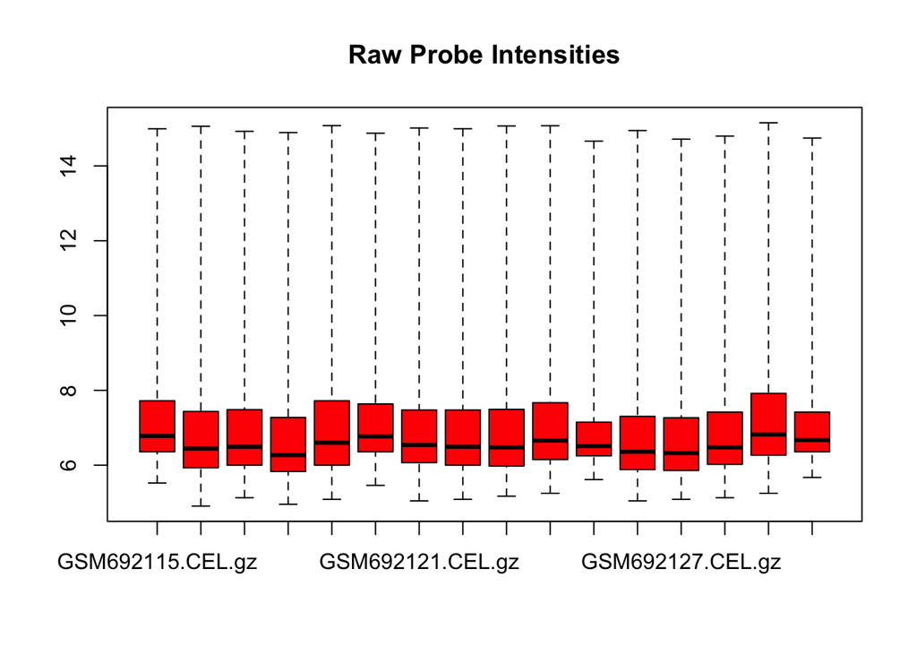

```r
boxplot(raw.data, col="red", main="Raw Probe Intensities")
```

None of the samples are outliers based on this plot.

- Perform RMA on the samples and create a new intensity boxplot.

```r
GSE27973.rma <- rma(raw.data)
```

```
## Background correcting
## Normalizing
## Calculating Expression
```

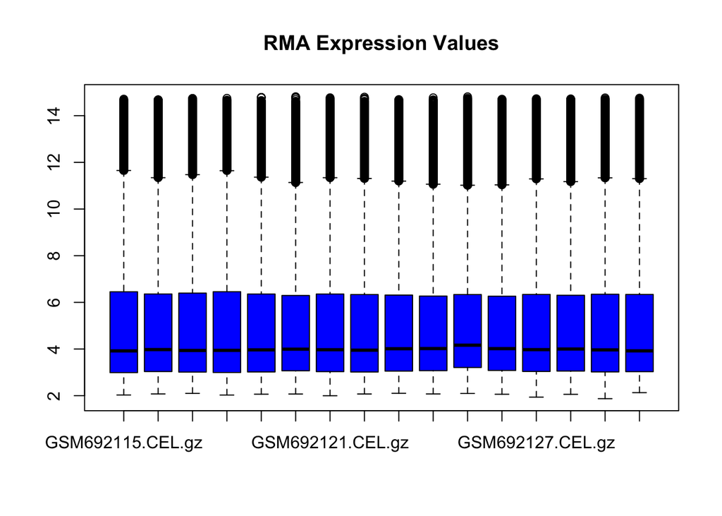

```r
boxplot(exprs(GSE27973.rma), col="blue", main="RMA Expression Values")
```

The intensity distribution of each sample is very similar now. The mean, range, and overall distribution of intensities across samples is uniform.

- Perform a differential expression analysis, and report how many probes are significantly differentially expressed between the *CSE* and *medium* samples based on a Benjamini-Hochberg corrected p-value threshold of 0.05.

```r
design <- model.matrix(~ -1+factor(GSE27973.rma$treatment))
colnames(design) <- levels(factor(GSE27973.rma$treatment))
fit <- lmFit(GSE27973.rma, design)
#Note: we only need one contrast to get the results of interest
GSE27973.contrast <- makeContrasts(smoke=CSE-medium, levels = design)
fit2 <- contrasts.fit(fit, GSE27973.contrast)
fit2 <- eBayes(fit2)

smoke_results <- topTable(fit2, coef="smoke" , adjust="BH", p.value=0.05, number=100)

smoke_results$ID = row.names(smoke_results)
smoke_results$SYMBOL <- lapply(smoke_results$ID, function(x) mget(x, env=hgu133plus2SYMBOL, ifnotfound=NA)[[1]])
smoke_results
```

```
##                   logFC   AveExpr         t      P.Value    adj.P.Val        B           ID  SYMBOL
## 201468_s_at   2.8767269  9.741714 15.089590 8.643445e-11 4.725803e-06 7.048890  201468_s_at    NQO1
## 210519_s_at   2.6595209 10.415728 13.235408 5.921987e-10 1.618923e-05 6.514388  210519_s_at    NQO1
## 205749_at     5.3230519  7.466117 12.078932 2.215863e-09 4.038411e-05 6.090601    205749_at  CYP1A1
## 201266_at     1.7996675 10.169665 11.620312 3.849137e-09 5.261289e-05 5.898546    201266_at  TXNRD1
## 201467_s_at   2.7365630  8.884938 11.342799 5.422582e-09 5.929594e-05 5.774850  201467_s_at    NQO1
## 202275_at     1.4636318  6.672740  9.631817 5.251507e-08 4.281798e-04 4.865306    202275_at    G6PD
## 241418_at     2.2731474  5.652694  9.601450 5.481954e-08 4.281798e-04 4.846560    241418_at NMRAL2P
## 202436_s_at   3.2787945 10.883149  9.221992 9.454984e-08 6.461891e-04 4.603564  202436_s_at  CYP1B1
## 214211_at     1.1745232 11.094682  8.637449 2.259981e-07 1.307852e-03 4.195493    214211_at    FTH1
## 202437_s_at   3.0689514  9.297821  8.600257 2.392047e-07 1.307852e-03 4.168058  202437_s_at  CYP1B1
## 209160_at     1.3892861 10.654167  8.511772 2.739928e-07 1.361869e-03 4.102047    209160_at  AKR1C3
## 202435_s_at   3.0314685  8.998794  8.084508 5.349470e-07 2.437352e-03 3.768199  202435_s_at  CYP1B1
## 1555856_s_at  1.2028430  4.215888  7.947188 6.664874e-07 2.803092e-03 3.655387 1555856_s_at  AKR1C1
## 225252_at     0.7930943  9.500336  7.295538 1.955554e-06 7.637138e-03 3.081008    225252_at   SRXN1
## 212665_at     1.0901839 10.447163  7.232964 2.174883e-06 7.927448e-03 3.022313    212665_at  TIPARP
## 204151_x_at   1.3962082 13.066429  6.945123 3.570607e-06 1.220144e-02 2.743949  204151_x_at  AKR1C1
## 216594_x_at   1.4760460 12.478651  6.848928 4.224564e-06 1.358694e-02 2.647800  216594_x_at  AKR1C1
## 225116_at     0.9206990  7.486130  6.613541 6.409462e-06 1.946874e-02 2.405769    225116_at   HIPK2
## 208161_s_at   1.0101351  7.034743  6.499188 7.869756e-06 2.264626e-02 2.284675  208161_s_at   ABCC3
## 213288_at     0.8420914  9.469226  6.242729 1.255190e-05 3.431375e-02 2.004586    213288_at  MBOAT2
## 232098_at    -0.8862679  5.929164 -6.197080 1.365240e-05 3.554499e-02 1.953483    232098_at     DST
## 210143_at     1.1555109  5.527350  6.161336 1.458393e-05 3.624439e-02 1.913205    210143_at  ANXA10
## 204059_s_at   0.6462498 10.120310  6.001492 1.963332e-05 4.609163e-02 1.730220  204059_s_at     ME1
## 211653_x_at   1.4962497 11.900921  5.985439 2.023227e-05 4.609163e-02 1.711583  211653_x_at  AKR1C2
## 207469_s_at   1.3282316  8.267462  5.943290 2.189691e-05 4.788855e-02 1.662426  207469_s_at     PIR
```

```r
dim(smoke_results)
```

```
## [1] 25  8
```

- What is the top differentially expressed gene? Create a boxplot of its normalized intensities across *all* treatment groups. How many probes corresponding to this gene are among the top hits?

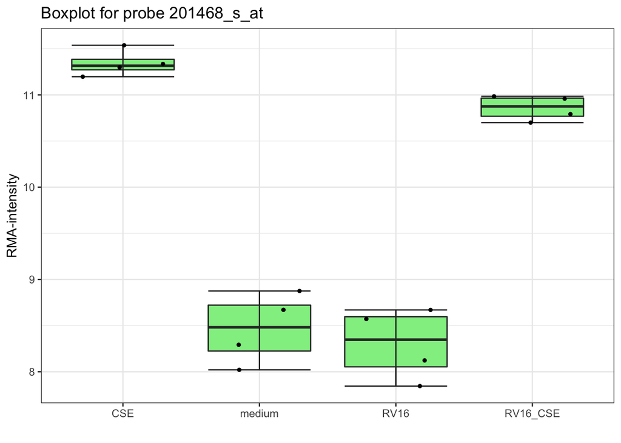

```r
library(ggplot2)
df_boxplot=data.frame(
  expression=exprs(GSE27973.rma)["201468_s_at", ],
  status=GSE27973.rma$treatment)

ggplot(df_boxplot, aes(x=status, y=expression)) +
  geom_boxplot(outlier.colour=NA, color="grey18", fill="lightgreen") +
  stat_boxplot(geom='errorbar', color="grey18") +
  geom_jitter(size=1, position=position_jitter(width=0.3)) +
  ggtitle("Boxplot for probe 201468_s_at") +
  xlab("")+
  ylab("RMA-intensity")+
  theme_bw() +
  theme(legend.position="none")
```

The top differentially expressed gene is *NQO1*. Three probes for this gene are among the top hits.

- Create a heatmap using the significantly differentially expressed genes and samples from all conditions. How do the treatment groups cluster? What does this indicate (a qualitative answer is sufficient)?

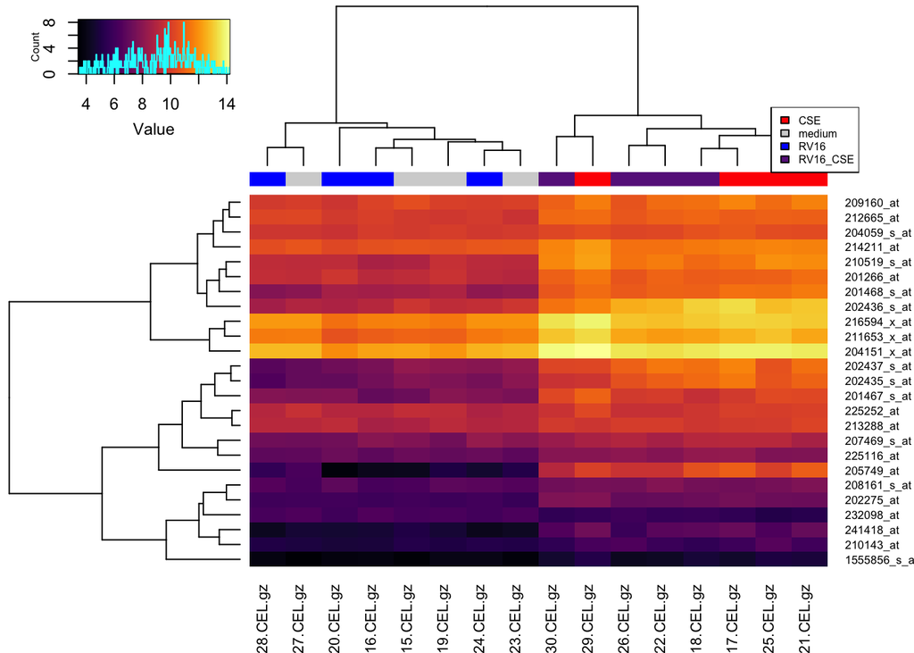

```r
library(gplots)
top.eset <- GSE27973.rma[row.names(exprs(GSE27973.rma)) %in% row.names(smoke_results)]
four.col <- c("red", "lightgrey", "blue", "darkorchid4")
status.colors <- sapply(as.numeric(factor(GSE27973.rma$treatment)), function(x) {four.col[x]})
heatmap.2(exprs(top.eset), col=viridis(256, option="B"),
          trace="none", keysize=1.5, key.title=NA, cexRow=0.8,
          ColSideColors=status.colors)
legend("topright", legend = c("CSE", "medium", "RV16", "RV16_CSE"),
    fill=four.col, cex=0.5)
```

The differential expression of genes in the two treatments that involve CSE exposure is similar (at least for this set of genes), while the control and rhinovirus samples are more similar to each other. Thus, for this set of genes, rhinovirus does not influence the expression of CSE-modified genes.